# Assigning ASVs with DADA2

Hilal Samut

March 11, 2025

# Goals

1. Infer an error model for in the filtered sequences, separately on forward and reverse reads.
2. Assign ASVs on both forward and reverse reads separately by applying the error model.
3. Merge forward and reverse ASVs into “contiguous ASVs”.
4. Generate the first draft of ASV count table.
5. Quality Trimming of ASV lengths.
6. Remove chimeras.
7. Assign Taxonomy with Silva Database.
8. Write out relevant files: `asv_table`, `asvs_fasta`, `tax_table`, and `sample_data`.

## Input

1. Filtered fastq files generated from `01_QualityTrimming.Rmd`.
2. Sample Name vector.

## Output

1. ASV Count Table: `asv_table` (with and without sequence names)
2. ASV fasta file: `asvs_fasta` for building a phylogenetic tree at a later step.
3. Taxonomy Table `tax_table`
4. Sample Information: `sample_data` track the reads lots throughout DADA2 workflow.

# Set up the Environment

## Set Seed & Threads

We need to be mindful of others when we are using the server. We learned in this lesson that we can use `top` and `htop` in the shell to see how many users are currently on the server. So, if you’re working through something outside of class, it’s ok to increase the number of threads. And, it will make everything go faster!

Then, when we have a `multithread` parameter, we can set it to be `multithread = n_threads`. If we notice more people on the server, we can modify the n_threads in this one location.

```r
# Set the seed for reproducibility
set.seed(238428)

# Let's make a parameter to set the number of threads
n_threads = 20
```

## Timing of this script

Let’s record how long this file took to run on the class server, which we will record at the end of the script.

```r
# What time did we start running this script?
start_time <- Sys.time()
```

## Load Packages

```r
# Efficient package loading with pacman
pacman::p_load(tidyverse, devtools, dada2,
               patchwork, DT, install = FALSE)
```

## Load Filtered Fastq Files

```r
# Place filtered seq files into a variable
filtered_fastqs_path <- "data/01_DADA2/02_filtered_fastqs"

# Intuition check:
filtered_fastqs_path
```

```
## [1] "data/01_DADA2/02_filtered_fastqs"
```

```r
# Create Forward vector
filtered_forward_reads <-
  list.files(filtered_fastqs_path, pattern = "R1_filtered.fastq.gz",
             full.names = TRUE)
# Check
filtered_forward_reads[1:5]
```

```
## [1] "data/01_DADA2/02_filtered_fastqs/SRR17327669_R1_filtered.fastq.gz"
## [2] "data/01_DADA2/02_filtered_fastqs/SRR17327670_R1_filtered.fastq.gz"
## [3] "data/01_DADA2/02_filtered_fastqs/SRR17327671_R1_filtered.fastq.gz"
## [4] "data/01_DADA2/02_filtered_fastqs/SRR17327672_R1_filtered.fastq.gz"
## [5] "data/01_DADA2/02_filtered_fastqs/SRR17327673_R1_filtered.fastq.gz"
```

```r
# Reverse vector
filtered_reverse_reads <-
    list.files(filtered_fastqs_path, pattern = "R2_filtered.fastq.gz",
             full.names = TRUE)

# Check
filtered_reverse_reads[1:5]
```

```
## [1] "data/01_DADA2/02_filtered_fastqs/SRR17327669_R2_filtered.fastq.gz"
## [2] "data/01_DADA2/02_filtered_fastqs/SRR17327670_R2_filtered.fastq.gz"
## [3] "data/01_DADA2/02_filtered_fastqs/SRR17327671_R2_filtered.fastq.gz"
## [4] "data/01_DADA2/02_filtered_fastqs/SRR17327672_R2_filtered.fastq.gz"
## [5] "data/01_DADA2/02_filtered_fastqs/SRR17327673_R2_filtered.fastq.gz"
```

## Sample Names

```r
# Create vector of sample names from the filenames
sample_names <- sapply(strsplit(basename(filtered_forward_reads), "_"), `[`,1)

# Intuition Check
head(sample_names)
```

```
## [1] "SRR17327669" "SRR17327670" "SRR17327671" "SRR17327672" "SRR17327673"
## [6] "SRR17327674"
```

# Error Modelling

## How does it work?

This is the step along the workflow where we try to estimate what is a *mistake* from technological sequencing error versus what is *true biological variation*. Therefore, this step is another critical step that we need to be mindful of! This is also what makes DADA2 unique!

Specifically, we will infer error rates for all possible *transitions* within purines and pyrimidines (A<>G or C<>T) and *transversions* between all purine and pyrimidine combinations. The error model is learned by alternating estimation of the error rates and inference of sample composition until they converge. It starts with abundant sequences first and then goes to less abundant sequences. It will:

1. Starts with the assumption that the error rates are the maximum (takes the most abundant sequence (“center”) and assumes it’s the only sequence not caused by errors).
2. Compares the other sequences to the most abundant sequence.
3. Uses at most 10<sup>8</sup> nucleotides for the error estimation. (Though, sometimes we increase this parameter in the case of binned sequencing quality scores.)
4. Uses parametric error estimation function of loess fit on the observed error rates.

## Important Notes

**First, every individual sequencing run needs to have its own and separate error model!** This is because every sequencing run is unique—even if the flow cell and DNA/samples are *exactly the same*.

While you can combine multiple datasets together after running them through DADA2, if you’d like to limit bias and combine data sets from multiple sequencing runs, it is ideal to do the following:

1. Use the exact same DNA extractions and library prep (*e.g.* same primer sets).
2. Perform the exact same `filterAndTrim()`, with equivalent parameters between sequencing runs. This is because we need to have the exact same ASV length expected by the output of our filtering and trimming.
3. Assign ASVs on forward and reverse reads, merge them, and then once you have the ASV table from each sequencing run, you can merge them together.

But wait: *What contributes to sequencing error in different sequencing runs and why do we need to model errors separately per run with `learnErrors()` in dada2?* Remember the core principles of how Illumina sequencing works! Some things that contribute to this are:

1. Each sequencing run has a **unique timing for when clusters go out of sync** (*e.g.,* the drop in quality at end of reads, which is typical of Illumina sequencing. This decrease in read quality is especially true of older Illumina sequencing data and is improving with more recent technologies.
2. The **cluster density is impossible to replicate**. Therefore, the cluster density (and therefore sequence quality) will always be different between sequencing runs (even if it’s the same person/samples/sequencing facility!). This is getting easier to replicate with the newer flow cells (*e.g.,* patterned flow cells) but is not yet possible.
3. **PhiX spike-in will also vary between runs**, even if we try to make it the same! Therefore, the amount of heterogeneity on the flow cell will also be different, which further impacting the sequencing quality.
4. **Different locations on the flow cell can be impacted differently between runs.** Perhaps an air bubble can get in. Or, as mentioned above, the cluster density is higher and/or lower on a different run/flow cell. In the old, non-patterned flow cells, sometimes clusters can form nearby each other. However, this has been solved on the new, patterned flow cells where clusters have a specific distance between each other.

**Second, this step uses our quality scores, which is rapidly changing with new sequencing technologies!** Therefore, we need to be mindful of how we run our error models. The traditional error models were developed based on the 40 Phred scores that were generated by early Illumina Sequencing technologies. However, with the new binned quality scores, we need to incorporate new ways of error modeling and this is constantly changing right now, which you can see in this [very active discussion on the DADA2 GitHub page](https://github.com/benjjneb/dada2/issues/1307).

Now, let’s consider the two types of Illumina data output and how it might inform our error modeling.

## Learn the Errors

### MiSeq Runs: 40 Phred Scores

Here, in the data we have sequenced here, we have Illumina MiSeq data with the traditional 40 Phred scores. Therefore, we can use the traditional `learnErrors()` command, which we will do below.

```r
# Forward Reads
error_forward_reads <-
  learnErrors(filtered_forward_reads, multithread = n_threads)
```

```
## 112602322 total bases in 473119 reads from 2 samples will be used for learning the error rates.
```

```r
# Forward Error Plot
forward_error_plot <-
  plotErrors(error_forward_reads, nominalQ = TRUE) +
  labs(title = "Forward Reads: Error Model")

# Reverse Reads
error_reverse_reads <-
  learnErrors(filtered_reverse_reads, multithread = n_threads)
```

```
## 141462909 total bases in 748481 reads from 3 samples will be used for learning the error rates.
```

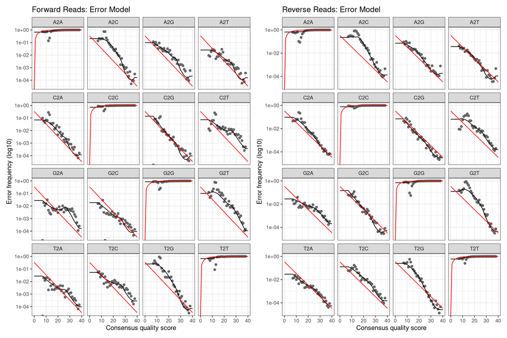

```r
# Reverse Error Plot
reverse_error_plot <-
  plotErrors(error_reverse_reads, nominalQ = TRUE) +
  labs(title = "Reverse Reads: Error Model")

# Look at the plots together
forward_error_plot + reverse_error_plot
```

The above plot represents the error rates for each possible transition (A→C, A→G, …) in the forward reads (on the left) and the reverse reads (on the right).

Details of the plots above: - **Points**: The observed error rates for each consensus quality score.  
- **Black line**: Estimated error rates after convergence of the machine-learning algorithm.  
- **Red line:** The error rates expected under the nominal definition of the Q-score.

Similar to what is mentioned in the [DADA2 tutorial](https://benjjneb.github.io/dada2/tutorial_1_8.html): the estimated error rates (black line) are a “reasonably good” fit to the observed rates (points), and the error rates drop with increased quality as expected. We can now infer ASVs!

# Infer ASVs

**An important note:** What makes DADA2 so nice is that it infers ASVs separately on the forward and the reverse reads and then merges them afterwards. This is quite a different approach from how OTUs are identified in Mothur and also from UCHIME, oligotyping, and other OTU, MED, and ASV approaches.

```r
# Infer ASVs on the forward sequences
dada_forward <-
  dada(filtered_forward_reads,
       err = error_forward_reads,
       multithread = n_threads)
```

```
## Sample 1 - 237469 reads in 33558 unique sequences.
## Sample 2 - 235650 reads in 32388 unique sequences.
## Sample 3 - 275362 reads in 37834 unique sequences.
## Sample 4 - 243698 reads in 23595 unique sequences.
## Sample 5 - 242980 reads in 30895 unique sequences.
## Sample 6 - 293088 reads in 36170 unique sequences.
## Sample 7 - 244867 reads in 22375 unique sequences.
## Sample 8 - 211242 reads in 18878 unique sequences.
## Sample 9 - 211083 reads in 20490 unique sequences.
## Sample 10 - 227895 reads in 20365 unique sequences.
## Sample 11 - 149648 reads in 25827 unique sequences.
## Sample 12 - 242989 reads in 34706 unique sequences.
## Sample 13 - 282242 reads in 40579 unique sequences.
## Sample 14 - 235059 reads in 33219 unique sequences.
## Sample 15 - 313982 reads in 43405 unique sequences.
## Sample 16 - 247524 reads in 36861 unique sequences.
## Sample 17 - 268748 reads in 37350 unique sequences.
## Sample 18 - 241938 reads in 31833 unique sequences.
## Sample 19 - 234219 reads in 29938 unique sequences.
## Sample 20 - 291773 reads in 42994 unique sequences.
## Sample 21 - 244766 reads in 36783 unique sequences.
## Sample 22 - 124068 reads in 22005 unique sequences.
## Sample 23 - 228556 reads in 26122 unique sequences.
## Sample 24 - 242880 reads in 30240 unique sequences.
## Sample 25 - 221797 reads in 25559 unique sequences.
## Sample 26 - 216609 reads in 28867 unique sequences.
## Sample 27 - 234546 reads in 20623 unique sequences.
## Sample 28 - 133257 reads in 13304 unique sequences.
## Sample 29 - 217907 reads in 20588 unique sequences.
## Sample 30 - 234124 reads in 24493 unique sequences.
## Sample 31 - 271244 reads in 39710 unique sequences.
## Sample 32 - 258066 reads in 34956 unique sequences.
## Sample 33 - 141672 reads in 25912 unique sequences.
## Sample 34 - 272022 reads in 42932 unique sequences.
## Sample 35 - 252064 reads in 32670 unique sequences.
## Sample 36 - 297872 reads in 42020 unique sequences.
## Sample 37 - 265249 reads in 36791 unique sequences.
## Sample 38 - 213572 reads in 24341 unique sequences.
## Sample 39 - 238145 reads in 30155 unique sequences.
## Sample 40 - 219855 reads in 26960 unique sequences.
```

[output cut: 53 more lines]

```
## Sample 94 - 136108 reads in 26549 unique sequences.
## Sample 95 - 159243 reads in 25553 unique sequences.
## Sample 96 - 155582 reads in 29338 unique sequences.
## Sample 97 - 168974 reads in 33171 unique sequences.
## Sample 98 - 260395 reads in 42322 unique sequences.
## Sample 99 - 254679 reads in 38912 unique sequences.
## Sample 100 - 260272 reads in 42126 unique sequences.
## Sample 101 - 246930 reads in 37487 unique sequences.
## Sample 102 - 264335 reads in 37566 unique sequences.
## Sample 103 - 248167 reads in 34736 unique sequences.
## Sample 104 - 197301 reads in 31276 unique sequences.
## Sample 105 - 146412 reads in 20856 unique sequences.
## Sample 106 - 157222 reads in 25690 unique sequences.
## Sample 107 - 179963 reads in 23699 unique sequences.
## Sample 108 - 143471 reads in 19745 unique sequences.
```

```r
# Take a look at the data
# What type of data structure is it?
typeof(dada_forward) # It's a list
```

```
## [1] "list"
```

```r
length(dada_forward) # How big is it? One per sample!
```

```
## [1] 108
```

```r
# What does it look like for each sample?
dada_forward$SRR17327669_R1_filtered.fastq.gz
```

```
## dada-class: object describing DADA2 denoising results
## 380 sequence variants were inferred from 33558 input unique sequences.
## Key parameters: OMEGA_A = 1e-40, OMEGA_C = 1e-40, BAND_SIZE = 16
```

```r
# Reverse ASVs
dada_reverse <-
  dada(filtered_reverse_reads,
       err = error_reverse_reads ,
       multithread = n_threads)
```

```
## Sample 1 - 237469 reads in 30871 unique sequences.
## Sample 2 - 235650 reads in 32229 unique sequences.
## Sample 3 - 275362 reads in 37402 unique sequences.
## Sample 4 - 243698 reads in 26134 unique sequences.
## Sample 5 - 242980 reads in 32947 unique sequences.
## Sample 6 - 293088 reads in 35679 unique sequences.
## Sample 7 - 244867 reads in 24992 unique sequences.
## Sample 8 - 211242 reads in 22443 unique sequences.
## Sample 9 - 211083 reads in 22611 unique sequences.
## Sample 10 - 227895 reads in 22422 unique sequences.
## Sample 11 - 149648 reads in 32551 unique sequences.
## Sample 12 - 242989 reads in 31863 unique sequences.
## Sample 13 - 282242 reads in 37369 unique sequences.
## Sample 14 - 235059 reads in 33134 unique sequences.
## Sample 15 - 313982 reads in 41302 unique sequences.
## Sample 16 - 247524 reads in 35193 unique sequences.
## Sample 17 - 268748 reads in 34832 unique sequences.
## Sample 18 - 241938 reads in 29401 unique sequences.
## Sample 19 - 234219 reads in 31593 unique sequences.
## Sample 20 - 291773 reads in 38247 unique sequences.
## Sample 21 - 244766 reads in 37846 unique sequences.
## Sample 22 - 124068 reads in 28082 unique sequences.
## Sample 23 - 228556 reads in 32906 unique sequences.
## Sample 24 - 242880 reads in 30488 unique sequences.
## Sample 25 - 221797 reads in 29355 unique sequences.
## Sample 26 - 216609 reads in 29682 unique sequences.
## Sample 27 - 234546 reads in 24474 unique sequences.
## Sample 28 - 133257 reads in 15291 unique sequences.
## Sample 29 - 217907 reads in 23534 unique sequences.
## Sample 30 - 234124 reads in 27889 unique sequences.
## Sample 31 - 271244 reads in 37483 unique sequences.
## Sample 32 - 258066 reads in 33438 unique sequences.
## Sample 33 - 141672 reads in 32134 unique sequences.
## Sample 34 - 272022 reads in 38854 unique sequences.
## Sample 35 - 252064 reads in 32115 unique sequences.
## Sample 36 - 297872 reads in 38459 unique sequences.
## Sample 37 - 265249 reads in 32784 unique sequences.
## Sample 38 - 213572 reads in 26029 unique sequences.
## Sample 39 - 238145 reads in 30931 unique sequences.
## Sample 40 - 219855 reads in 27832 unique sequences.
```

[output cut: 53 more lines]

```
## Sample 94 - 136108 reads in 31909 unique sequences.
## Sample 95 - 159243 reads in 35142 unique sequences.
## Sample 96 - 155582 reads in 35087 unique sequences.
## Sample 97 - 168974 reads in 40207 unique sequences.
## Sample 98 - 260395 reads in 38640 unique sequences.
## Sample 99 - 254679 reads in 40195 unique sequences.
## Sample 100 - 260272 reads in 37106 unique sequences.
## Sample 101 - 246930 reads in 33102 unique sequences.
## Sample 102 - 264335 reads in 34137 unique sequences.
## Sample 103 - 248167 reads in 32804 unique sequences.
## Sample 104 - 197301 reads in 28886 unique sequences.
## Sample 105 - 146412 reads in 21925 unique sequences.
## Sample 106 - 157222 reads in 36741 unique sequences.
## Sample 107 - 179963 reads in 37032 unique sequences.
## Sample 108 - 143471 reads in 28729 unique sequences.
```

```r
# Check data
dada_reverse[30]
```

```
## $SRR17327698_R2_filtered.fastq.gz
## dada-class: object describing DADA2 denoising results
## 136 sequence variants were inferred from 27889 input unique sequences.
## Key parameters: OMEGA_A = 1e-40, OMEGA_C = 1e-40, BAND_SIZE = 16
```

# Merge Forward and Reverse ASVs

Now, that we have identified our ASVs separately on both the forward and the reverse reads, let’s **merge** them together into contiguous (*aka* “contigs”) ASVs.

```r
merged_ASVs <-
  mergePairs(dada_forward, filtered_forward_reads,
             dada_reverse, filtered_reverse_reads,
             verbose = TRUE)
```

```
## 80428 paired-reads (in 148 unique pairings) successfully merged out of 236531 (in 1911 pairings) input.
```

```
## 104805 paired-reads (in 203 unique pairings) successfully merged out of 234818 (in 1990 pairings) input.
```

```
## 109210 paired-reads (in 183 unique pairings) successfully merged out of 274208 (in 2081 pairings) input.
```

```
## 179010 paired-reads (in 195 unique pairings) successfully merged out of 243252 (in 763 pairings) input.
```

```
## 128568 paired-reads (in 212 unique pairings) successfully merged out of 242121 (in 2088 pairings) input.
```

```
## 149039 paired-reads (in 259 unique pairings) successfully merged out of 292240 (in 1806 pairings) input.
```

```
## 209896 paired-reads (in 186 unique pairings) successfully merged out of 244405 (in 727 pairings) input.
```

```
## 156172 paired-reads (in 144 unique pairings) successfully merged out of 210807 (in 490 pairings) input.
```

```
## 160015 paired-reads (in 146 unique pairings) successfully merged out of 210709 (in 546 pairings) input.
```

```
## 207804 paired-reads (in 179 unique pairings) successfully merged out of 227459 (in 642 pairings) input.
```

```
## 25369 paired-reads (in 102 unique pairings) successfully merged out of 149230 (in 1389 pairings) input.
```

```
## 23377 paired-reads (in 79 unique pairings) successfully merged out of 242312 (in 1884 pairings) input.
```

```
## 31551 paired-reads (in 112 unique pairings) successfully merged out of 281312 (in 2276 pairings) input.
```

```
## 24950 paired-reads (in 92 unique pairings) successfully merged out of 234087 (in 1713 pairings) input.
```

```
## 65047 paired-reads (in 214 unique pairings) successfully merged out of 312894 (in 3103 pairings) input.
```

```
## 58665 paired-reads (in 171 unique pairings) successfully merged out of 246417 (in 2303 pairings) input.
```

```
## 58047 paired-reads (in 155 unique pairings) successfully merged out of 267819 (in 2032 pairings) input.
```

```
## 67045 paired-reads (in 122 unique pairings) successfully merged out of 241365 (in 1392 pairings) input.
```

```
## 65672 paired-reads (in 135 unique pairings) successfully merged out of 233454 (in 1295 pairings) input.
```

```
## 75918 paired-reads (in 164 unique pairings) successfully merged out of 290816 (in 2781 pairings) input.
```

```
## 63311 paired-reads (in 170 unique pairings) successfully merged out of 243677 (in 2702 pairings) input.
```

```
## 19780 paired-reads (in 71 unique pairings) successfully merged out of 123648 (in 1342 pairings) input.
```

```
## 136380 paired-reads (in 181 unique pairings) successfully merged out of 227995 (in 940 pairings) input.
```

```
## 124197 paired-reads (in 188 unique pairings) successfully merged out of 241969 (in 1558 pairings) input.
```

```
## 112678 paired-reads (in 188 unique pairings) successfully merged out of 221004 (in 1502 pairings) input.
```

```
## 83730 paired-reads (in 179 unique pairings) successfully merged out of 215945 (in 1628 pairings) input.
```

```
## 209327 paired-reads (in 185 unique pairings) successfully merged out of 234092 (in 712 pairings) input.
```

```
## 97083 paired-reads (in 106 unique pairings) successfully merged out of 132990 (in 383 pairings) input.
```

```
## 157753 paired-reads (in 157 unique pairings) successfully merged out of 217607 (in 531 pairings) input.
```

```
## 165239 paired-reads (in 168 unique pairings) successfully merged out of 233616 (in 1062 pairings) input.
```

```
## 47670 paired-reads (in 147 unique pairings) successfully merged out of 270374 (in 2340 pairings) input.
```

```
## 50241 paired-reads (in 98 unique pairings) successfully merged out of 257402 (in 1660 pairings) input.
```

```
## 32357 paired-reads (in 117 unique pairings) successfully merged out of 141061 (in 1514 pairings) input.
```

```
## 37742 paired-reads (in 119 unique pairings) successfully merged out of 270652 (in 2611 pairings) input.
```

```
## 134444 paired-reads (in 210 unique pairings) successfully merged out of 251119 (in 1847 pairings) input.
```

```
## 115472 paired-reads (in 190 unique pairings) successfully merged out of 296694 (in 1944 pairings) input.
```

```
## 129191 paired-reads (in 252 unique pairings) successfully merged out of 264108 (in 2055 pairings) input.
```

```
## 53838 paired-reads (in 99 unique pairings) successfully merged out of 213132 (in 771 pairings) input.
```

```
## 75576 paired-reads (in 136 unique pairings) successfully merged out of 237456 (in 1270 pairings) input.
```

```
## 132412 paired-reads (in 176 unique pairings) successfully merged out of 219139 (in 1187 pairings) input.
```

```
## 140307 paired-reads (in 147 unique pairings) successfully merged out of 204606 (in 719 pairings) input.
```

```
## 168816 paired-reads (in 194 unique pairings) successfully merged out of 249128 (in 824 pairings) input.
```

```
## 230216 paired-reads (in 189 unique pairings) successfully merged out of 265906 (in 578 pairings) input.
```

```
## 15015 paired-reads (in 59 unique pairings) successfully merged out of 113415 (in 1216 pairings) input.
```

```
## 110609 paired-reads (in 168 unique pairings) successfully merged out of 232898 (in 1622 pairings) input.
```

```
## 51972 paired-reads (in 124 unique pairings) successfully merged out of 309274 (in 3239 pairings) input.
```

```
## 149221 paired-reads (in 176 unique pairings) successfully merged out of 198698 (in 820 pairings) input.
```

```
## 148328 paired-reads (in 153 unique pairings) successfully merged out of 224105 (in 862 pairings) input.
```

```
## 184227 paired-reads (in 161 unique pairings) successfully merged out of 248122 (in 617 pairings) input.
```

```
## 230626 paired-reads (in 220 unique pairings) successfully merged out of 268023 (in 792 pairings) input.
```

```
## 34129 paired-reads (in 108 unique pairings) successfully merged out of 158897 (in 1840 pairings) input.
```

```
## 37338 paired-reads (in 95 unique pairings) successfully merged out of 153507 (in 1660 pairings) input.
```

```
## 17455 paired-reads (in 64 unique pairings) successfully merged out of 149041 (in 1980 pairings) input.
```

```
## 99949 paired-reads (in 125 unique pairings) successfully merged out of 140717 (in 533 pairings) input.
```

```
## 69061 paired-reads (in 134 unique pairings) successfully merged out of 141627 (in 1141 pairings) input.
```

```
## 158258 paired-reads (in 116 unique pairings) successfully merged out of 205283 (in 451 pairings) input.
```

```
## 142298 paired-reads (in 102 unique pairings) successfully merged out of 168854 (in 412 pairings) input.
```

```
## 62049 paired-reads (in 150 unique pairings) successfully merged out of 191926 (in 1625 pairings) input.
```

```
## 60368 paired-reads (in 129 unique pairings) successfully merged out of 154533 (in 1190 pairings) input.
```

```
## 91895 paired-reads (in 180 unique pairings) successfully merged out of 191253 (in 1449 pairings) input.
```

```
## 75551 paired-reads (in 119 unique pairings) successfully merged out of 134904 (in 874 pairings) input.
```

```
## 23152 paired-reads (in 63 unique pairings) successfully merged out of 141246 (in 882 pairings) input.
```

```
## 82116 paired-reads (in 145 unique pairings) successfully merged out of 126839 (in 710 pairings) input.
```

```
## 83948 paired-reads (in 179 unique pairings) successfully merged out of 161782 (in 1919 pairings) input.
```

```
## 62863 paired-reads (in 119 unique pairings) successfully merged out of 143646 (in 1135 pairings) input.
```

```
## 75533 paired-reads (in 120 unique pairings) successfully merged out of 150638 (in 841 pairings) input.
```

```
## 162603 paired-reads (in 195 unique pairings) successfully merged out of 191456 (in 822 pairings) input.
```

```
## 104115 paired-reads (in 124 unique pairings) successfully merged out of 150480 (in 777 pairings) input.
```

```
## 102516 paired-reads (in 120 unique pairings) successfully merged out of 134506 (in 492 pairings) input.
```

```
## 118329 paired-reads (in 144 unique pairings) successfully merged out of 139189 (in 485 pairings) input.
```

```
## 46263 paired-reads (in 127 unique pairings) successfully merged out of 202846 (in 2267 pairings) input.
```

```
## 28066 paired-reads (in 112 unique pairings) successfully merged out of 159368 (in 1719 pairings) input.
```

```
## 28286 paired-reads (in 100 unique pairings) successfully merged out of 132901 (in 1659 pairings) input.
```

```
## 61540 paired-reads (in 129 unique pairings) successfully merged out of 210704 (in 1528 pairings) input.
```

```
## 59868 paired-reads (in 125 unique pairings) successfully merged out of 174195 (in 1396 pairings) input.
```

```
## 68097 paired-reads (in 148 unique pairings) successfully merged out of 171817 (in 1348 pairings) input.
```

```
## 86417 paired-reads (in 160 unique pairings) successfully merged out of 125787 (in 552 pairings) input.
```

```
## 62883 paired-reads (in 150 unique pairings) successfully merged out of 212246 (in 1697 pairings) input.
```

```
## 77840 paired-reads (in 131 unique pairings) successfully merged out of 210951 (in 1573 pairings) input.
```

```
## 95730 paired-reads (in 156 unique pairings) successfully merged out of 155625 (in 869 pairings) input.
```

```
## 95110 paired-reads (in 163 unique pairings) successfully merged out of 176075 (in 1000 pairings) input.
```

```
## 81475 paired-reads (in 140 unique pairings) successfully merged out of 135970 (in 785 pairings) input.
```

```
## 99455 paired-reads (in 139 unique pairings) successfully merged out of 153776 (in 798 pairings) input.
```

```
## 38836 paired-reads (in 114 unique pairings) successfully merged out of 116874 (in 1694 pairings) input.
```

```
## 36361 paired-reads (in 136 unique pairings) successfully merged out of 162655 (in 1993 pairings) input.
```

```
## 40865 paired-reads (in 144 unique pairings) successfully merged out of 130604 (in 1415 pairings) input.
```

```
## 71258 paired-reads (in 109 unique pairings) successfully merged out of 128760 (in 683 pairings) input.
```

```
## 82641 paired-reads (in 178 unique pairings) successfully merged out of 189436 (in 1730 pairings) input.
```

```
## 92417 paired-reads (in 160 unique pairings) successfully merged out of 194315 (in 868 pairings) input.
```

```
## 77651 paired-reads (in 166 unique pairings) successfully merged out of 189299 (in 1247 pairings) input.
```

```
## 19728 paired-reads (in 88 unique pairings) successfully merged out of 114734 (in 1845 pairings) input.
```

```
## 27176 paired-reads (in 93 unique pairings) successfully merged out of 146953 (in 1781 pairings) input.
```

```
## 28734 paired-reads (in 115 unique pairings) successfully merged out of 190296 (in 2718 pairings) input.
```

```
## 23035 paired-reads (in 91 unique pairings) successfully merged out of 135528 (in 1790 pairings) input.
```

```
## 42226 paired-reads (in 131 unique pairings) successfully merged out of 158641 (in 1508 pairings) input.
```

```
## 23707 paired-reads (in 77 unique pairings) successfully merged out of 154916 (in 1592 pairings) input.
```

```
## 25279 paired-reads (in 108 unique pairings) successfully merged out of 168142 (in 2292 pairings) input.
```

```
## 44712 paired-reads (in 159 unique pairings) successfully merged out of 259130 (in 2970 pairings) input.
```

```
## 56530 paired-reads (in 179 unique pairings) successfully merged out of 253432 (in 2561 pairings) input.
```

```
## 21098 paired-reads (in 112 unique pairings) successfully merged out of 259138 (in 2981 pairings) input.
```

```
## 29342 paired-reads (in 95 unique pairings) successfully merged out of 245956 (in 2522 pairings) input.
```

```
## 69944 paired-reads (in 157 unique pairings) successfully merged out of 263432 (in 2117 pairings) input.
```

```
## 59843 paired-reads (in 142 unique pairings) successfully merged out of 247289 (in 1827 pairings) input.
```

```
## 44847 paired-reads (in 126 unique pairings) successfully merged out of 196340 (in 2337 pairings) input.
```

```
## 56402 paired-reads (in 97 unique pairings) successfully merged out of 145922 (in 1147 pairings) input.
```

```
## 58115 paired-reads (in 139 unique pairings) successfully merged out of 156473 (in 1583 pairings) input.
```

```
## 76725 paired-reads (in 158 unique pairings) successfully merged out of 179596 (in 864 pairings) input.
```

```
## 76850 paired-reads (in 179 unique pairings) successfully merged out of 142887 (in 893 pairings) input.
```

```r
# Evaluate the data output
typeof(merged_ASVs) # A list
```

```
## [1] "list"
```

```r
length(merged_ASVs) # Length of the number of samples!
```

```
## [1] 108
```

```r
head(names(merged_ASVs)) # Here, we can access our current sample names
```

```
## [1] "SRR17327669_R1_filtered.fastq.gz" "SRR17327670_R1_filtered.fastq.gz"
## [3] "SRR17327671_R1_filtered.fastq.gz" "SRR17327672_R1_filtered.fastq.gz"
## [5] "SRR17327673_R1_filtered.fastq.gz" "SRR17327674_R1_filtered.fastq.gz"
```

```r
# Inspect further for each sample
#head(merged_ASVs, n = 2) # A dataframe for each sample
# We have a dataframe in each part of our list! What are in the columns?
glimpse(merged_ASVs$SRR17327669_R1_filtered.fastq.gz)
```

```
## Rows: 148
## Columns: 9
## $ sequence  <chr> "AATTTTCCGCAATGGGCGAAAGCCTGACGGAGCAATGCCGCGTGGAGGTAGAAGGCCCA…
## $ abundance <int> 71968, 3021, 455, 385, 330, 264, 252, 247, 226, 202, 171, 13…
## $ forward   <int> 1, 13, 40, 41, 1, 45, 294, 48, 55, 58, 1, 66, 72, 147, 80, 1…
## $ reverse   <int> 1, 9, 17, 1, 68, 20, 1, 21, 1, 25, 26, 1, 2, 1, 22, 1, 22, 2…
## $ nmatch    <int> 28, 28, 28, 28, 29, 28, 28, 28, 28, 27, 28, 28, 28, 28, 25, …
## $ nmismatch <int> 0, 0, 0, 0, 0, 0, 0, 0, 0, 0, 0, 0, 0, 0, 0, 0, 0, 0, 0, 0, …
## $ nindel    <int> 0, 0, 0, 0, 0, 0, 0, 0, 0, 0, 0, 0, 0, 0, 0, 0, 0, 0, 0, 0, …
## $ prefer    <dbl> 1, 2, 2, 2, 1, 2, 2, 1, 2, 2, 1, 2, 2, 2, 2, 2, 2, 2, 2, 2, …
## $ accept    <lgl> TRUE, TRUE, TRUE, TRUE, TRUE, TRUE, TRUE, TRUE, TRUE, TRUE, …
```

# Create Raw ASV Count Table

```r
# Raw ASV
raw_ASV_table <- makeSequenceTable(merged_ASVs)

# Intuition Check: Type and dimensions of the data
dim(raw_ASV_table)
```

```
## [1]  108 3047
```

```r
typeof(raw_ASV_table)
```

```
## [1] "integer"
```

```r
class(raw_ASV_table)
```

```
## [1] "matrix" "array"
```

```r
# write out raw_asv_table
write.table(raw_ASV_table, file = "data/01_DADA2/raw_ASV_counts.tsv",
            sep = "\t", quote = FALSE, col.names = NA)
```

# Assess ASV Quality

## What are the current ASV lengths?

First, let’s inspect the distribution of the ASV sequence lengths across all of the ASVs that we have inferred. First, we need to consider: **What is the expected length of the ASVs?**

### ASV Length Stats

```r
# Calculate summary stats
# Longest ASV?
maxLength_ASV <- max(nchar(getSequences(raw_ASV_table)))

# Shortest ASV?
minLength_ASV <- min(nchar(getSequences(raw_ASV_table)))

# Mean ASV length?
meanLength_ASV <- mean(nchar(getSequences(raw_ASV_table)))

# Median ASV length?
medianLength_ASV <- median(nchar(getSequences(raw_ASV_table)))

# Create a table to Inspect the distribution of sequence lengths of all ASVs in dataset
table(nchar(getSequences(raw_ASV_table)))
```

```
##
##  238  239  242  243  244  246  247  248  249  252  253  254  255  256  258  262
##   21    1    1    1    1    1    2    2    1    1    3    3   26    1    1    1
##  264  265  266  269  270  276  278  281  285  289  292  293  296  297  302  307
##    1    1    2    1    1    2    1    5    4    1    1    1    2    1    1    2
##  310  314  317  320  334  337  338  340  342  343  344  346  349  354  355  357
##    1    3    1    1    2    1    1    1    1    1    1    1    1    1    1    2
##  362  366  367  369  375  376  381  391  394  395  396  397  398  399  400  401
##    1    1    3    1   14    1    1    1    2    3   17  357   95 2005   30  257
##  402  403  404  405  406  407  408  410  411  412  413  414  415
##  108    4    8    6    2    1    1    1    1    1    3    1    7
```

Here’s some of the stats that we’ve calculated:

- Max ASV length: 415 base pairs
- Min ASV length: 238 base pairs
- Mean ASV length: 394.159173 base pairs
- Median ASV length: 399 base pairs

However, the median length actually is about what we are expecting, which is great. *Let’s take a look at what this looks like graphically!*

### ASV Length Plot

Now, we will plot these ASV lengths to give us a better idea:

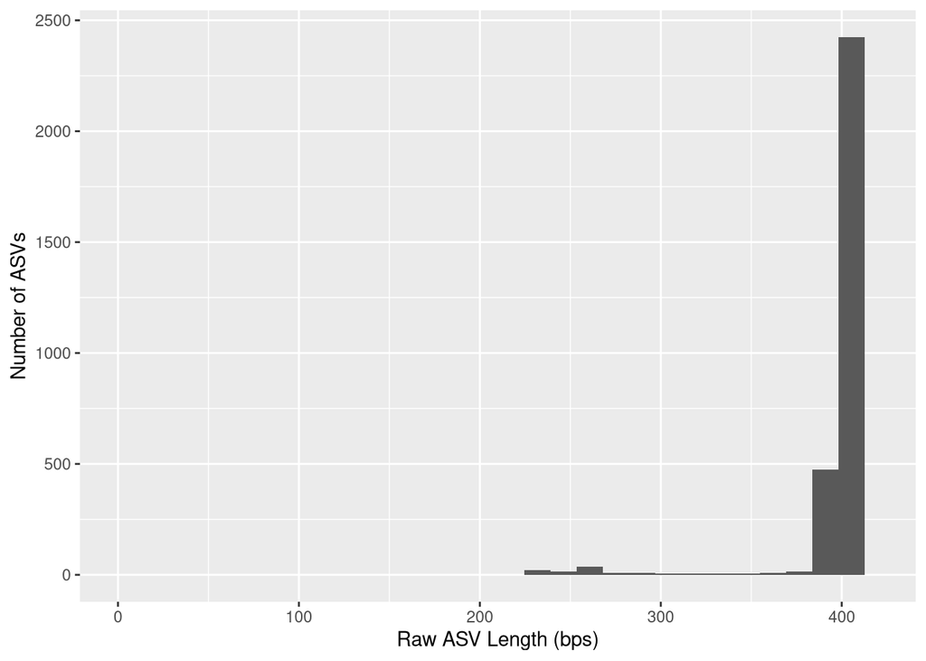

```r
# Inspect the distribution of sequence lengths of all ASVs in data set
# BEFORE TRIM
plot_ASVLength_raw <-
  data.frame(Seq_Length = nchar(getSequences(raw_ASV_table))) %>%
  ggplot(aes(x = Seq_Length )) +
  geom_histogram() +
  # include the x-axis scales
  scale_x_continuous(limits = c(0, maxLength_ASV + 5)) +
  labs(y = "Number of ASVs", x = "Raw ASV Length (bps)")

# Show the plot
plot_ASVLength_raw
```

INTERPRETATION #2: As we saw in the table, the length of the ASVs is mostly 399 base pairs. This is shorter than what I would expect according to the calculations above. Most of the ASVs have a length changing between 397 and 402. In total, 2005 ASVs are 399 bp in length, alongside with some other ASVs of shorter and longer lengths.

INTERPRETATION #3: I will maintain ASVs with lengths changing between 399 and 401 bp, allowing for variation in ASV length. The reason why I’d like to keep the ASVs 401bp is that there are 257 ASVs at this length. When I kept only ASVs of 399 bp length, what I observed was more than 1500 ASVs were detected as chimeras in downstream analysis, resulting in 477 ASVs of 399 bp length. When I only work with ASVs of 401 bp length, retention of ASVs is slightly better after removal of chimeras. Therefore, I decided to include ASVs ranging from 399 to 401 bp.

## Trim ASV lengths

**NOTE:** This is another moment in our workflow where we are sub-setting only the “good parts” of our data to ensure the data quality we have at the end is the best of our ability based on the sequencing run.

*Let’s trim the ASVs to 399-401 bp!*

```r
# Subset only ASVs that are ranging from 399-401 bps long
raw_ASV_table_trimmed <-
  raw_ASV_table[, nchar(colnames(raw_ASV_table)) == 399 |
                  nchar(colnames(raw_ASV_table)) == 400 |
                  nchar(colnames(raw_ASV_table)) == 401 ]

# Inspect the distribution of sequence lengths of all ASVs in dataset
table(nchar(getSequences(raw_ASV_table_trimmed)))
```

```
##
##  399  400  401
## 2005   30  257
```

```r
# What proportion of total ASV sequences are left in the data?
percRetained_Trimmed <- sum(raw_ASV_table_trimmed)/sum(raw_ASV_table)
percRetained_Trimmed # Show it
```

```
## [1] 0.9842744
```

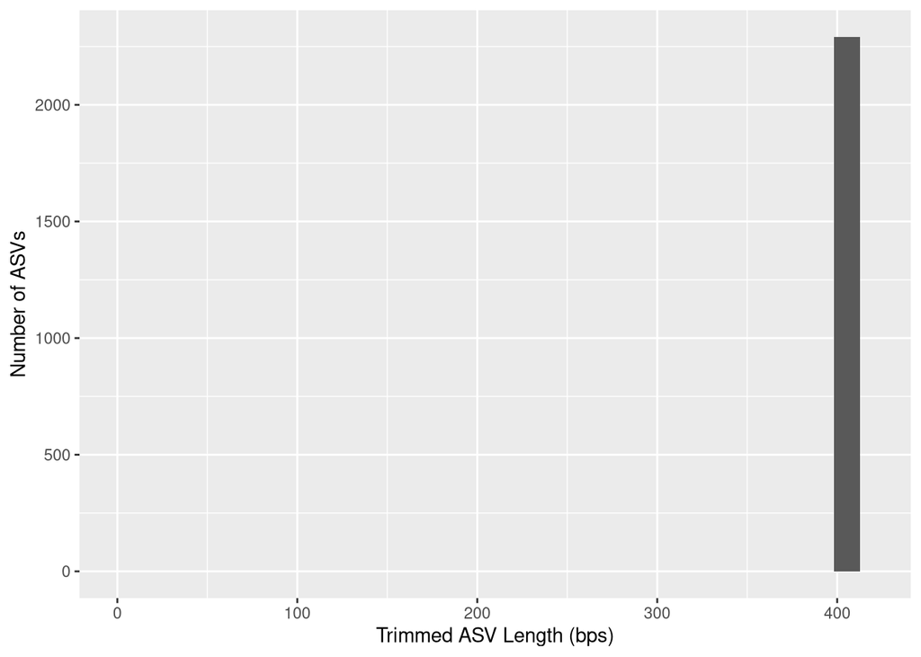

```r
# Inspect the distribution of sequence lengths of all ASVs in dataset
# AFTER TRIM
plot_ASVLength_trimmed <-
  data.frame(Seq_Length = nchar(getSequences(raw_ASV_table_trimmed))) %>%
  ggplot(aes(x = Seq_Length )) +
  geom_histogram() +
  # include the x-axis scales
  scale_x_continuous(limits = c(0, maxLength_ASV + 5)) +
  labs(y = "Number of ASVs", x = "Trimmed ASV Length (bps)")

# Show the plot
plot_ASVLength_trimmed
```

**Note the peak is ABOVE 2000 ASVs!** Now, we have ASV lengths that are ranging from 399-401 bp and we can move forward onto the next quality control step: removing chimeras.

# Remove Chimeras

## What is a chimera?

In 16S rRNA gene sequencing, a **chimera** is an artificial DNA sequence that forms when two or more different DNA templates are mistakenly and erroneously fused together during PCR amplification. **Chimeric sequences do not represent real organisms and must be removed during data processing to avoid false species identifications!** Chimeras are natural artifacts in PCR, especially in high-cycle (>25 cycle) PCR reactions, which are typical in library preparation and sequencing workflows. They arise during:

1. *Incomplete Extension in Early PCR Cycles.* During early PCR cycles, a DNA fragment may partially amplify before the polymerase detaches. This incomplete product remains in the reaction mixture.
2. *Template Switching in Later PCR Cycles.* In subsequent cycles, the polymerase may bind to and extend a different but similar template, rather than the original one. This results in a hybrid (chimeric) DNA molecule made of two unrelated 16S rRNA gene fragments.
3. *There is increased chimera formation in high-diversity samples.* More diverse microbial communities increase the chance of chimeric formation due to similar overlapping sequences in the sample. Longer PCR extension times and too many PCR cycles (>30) increase chimera formation by allowing more template switching.

## Chimeras must be removed

- **Chimeras create false ASVs:** Chimeric sequences do not belong to any real microbial species, leading to artificial diversity in sequencing results.
- **Chimeras can mislead ecological interpretations** If not removed, they can inflate richness estimates and misrepresent community composition.

Therefore, chimera removal is an essential step in the analysis of 16S sequencing data to improve the accuracy of downstream analyses, such as taxonomic assignment and diversity assessment. It helps to avoid the inclusion of misleading or spurious sequences that could lead to incorrect biological interpretations.

```r
# Remove the chimeras in the raw ASV table
noChimeras_ASV_table <-
  removeBimeraDenovo(raw_ASV_table_trimmed,
                     method="consensus",
                     multithread = n_threads,
                     verbose=TRUE)
```

```
## Identified 1756 bimeras out of 2292 input sequences.
```

```r
# Check the dimensions
dim(noChimeras_ASV_table)
```

```
## [1] 108 536
```

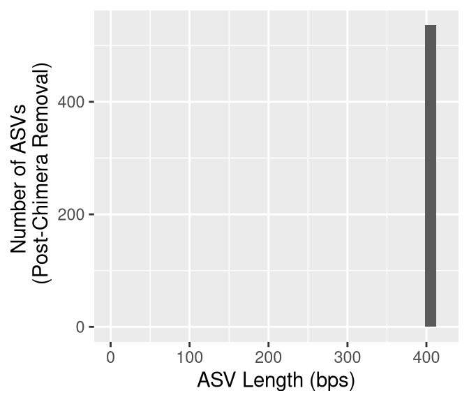

```r
# What proportion is left of the sequences?
# Chimera removal compared to trimming
percRetained_chimerasTrimmed <- sum(noChimeras_ASV_table)/sum(raw_ASV_table_trimmed)
# Chimera removal compared to raw
percRetained_chimerasRaw <- sum(noChimeras_ASV_table)/sum(raw_ASV_table)

# Plot it
plot_ASVLength_NoChimeras <-
  data.frame(Seq_Length_NoChim = nchar(getSequences(noChimeras_ASV_table))) %>%
  ggplot(aes(x = Seq_Length_NoChim )) +
  geom_histogram()+
  # include the x-axis scales
  scale_x_continuous(limits = c(0, maxLength_ASV + 5)) +
  labs(y = "Number of ASVs \n (Post-Chimera Removal)",
       x = "ASV Length (bps)")

# Show the plot
plot_ASVLength_NoChimeras
```

So, there is good retention of the ASVs after length trimming and chimera removal. However, there is variation in ASV lengths in the dataset after trimming and chimera removal.

### Plot ASV Lengths

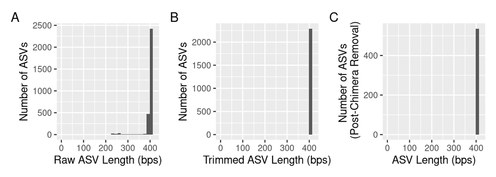

```r
plot_ASVLength_raw + plot_ASVLength_trimmed + plot_ASVLength_NoChimeras +
    plot_annotation(tag_levels = 'A')
```

# Track the read counts

Here, we will look at the number of reads that were lost in the filtering, denoising, merging, and chimera removal.

```r
# A little function to identify number seqs
getN <- function(x) sum(getUniques(x))

# Make the table to track the seqs
track <- cbind(sapply(dada_forward, getN),
               sapply(dada_reverse, getN),
               sapply(merged_ASVs, getN),
               rowSums(noChimeras_ASV_table))

head(track)
```

```
##                                    [,1]   [,2]   [,3]   [,4]
## SRR17327669_R1_filtered.fastq.gz 236818 237135  80428  78950
## SRR17327670_R1_filtered.fastq.gz 235028 235388 104805 103055
## SRR17327671_R1_filtered.fastq.gz 274451 275091 109210 107358
## SRR17327672_R1_filtered.fastq.gz 243401 243518 179010 175430
## SRR17327673_R1_filtered.fastq.gz 242325 242727 128568 126749
## SRR17327674_R1_filtered.fastq.gz 292421 292860 149039 146156
```

```r
# Update column names to be more informative (most are missing at the moment!)
colnames(track) <- c("denoisedF", "denoisedR", "merged", "nochim")
rownames(track) <- row.names(noChimeras_ASV_table)

# Generate a dataframe to track the reads through our DADA2 pipeline
track_counts_df <-
  track %>%
  # make it a dataframe
  as.data.frame() %>%
  rownames_to_column(var = "sample_names")

# Now let's add a column for the number of ASVs
# First, intuition check that the samples match
stopifnot(track_counts_df$sample_names == row.names(noChimeras_ASV_table))

# Now, let's add a new column with the number of ASVs
track_counts_df <-
  track_counts_df %>%
  mutate(num_ASVs = rowSums(noChimeras_ASV_table > 1))

# Visualize it in table format
DT::datatable(track_counts_df)
```

|  | sample_names | denoisedF | denoisedR | merged | nochim | num_ASVs |
| --- | --- | --- | --- | --- | --- | --- |
| 1 | SRR17327669_R1_filtered.fastq.gz | 236818 | 237135 | 80428 | 78950 | 59 |
| 2 | SRR17327670_R1_filtered.fastq.gz | 235028 | 235388 | 104805 | 103055 | 71 |
| 3 | SRR17327671_R1_filtered.fastq.gz | 274451 | 275091 | 109210 | 107358 | 62 |
| 4 | SRR17327672_R1_filtered.fastq.gz | 243401 | 243518 | 179010 | 175430 | 44 |
| 5 | SRR17327673_R1_filtered.fastq.gz | 242325 | 242727 | 128568 | 126749 | 64 |
| 6 | SRR17327674_R1_filtered.fastq.gz | 292421 | 292860 | 149039 | 146156 | 76 |
| 7 | SRR17327675_R1_filtered.fastq.gz | 244539 | 244686 | 209896 | 206423 | 47 |
| 8 | SRR17327676_R1_filtered.fastq.gz | 210939 | 211054 | 156172 | 153803 | 28 |
| 9 | SRR17327677_R1_filtered.fastq.gz | 210851 | 210903 | 160015 | 157227 | 37 |
| 10 | SRR17327678_R1_filtered.fastq.gz | 227570 | 227724 | 207804 | 204380 | 47 |

[output cut: 98 more lines]

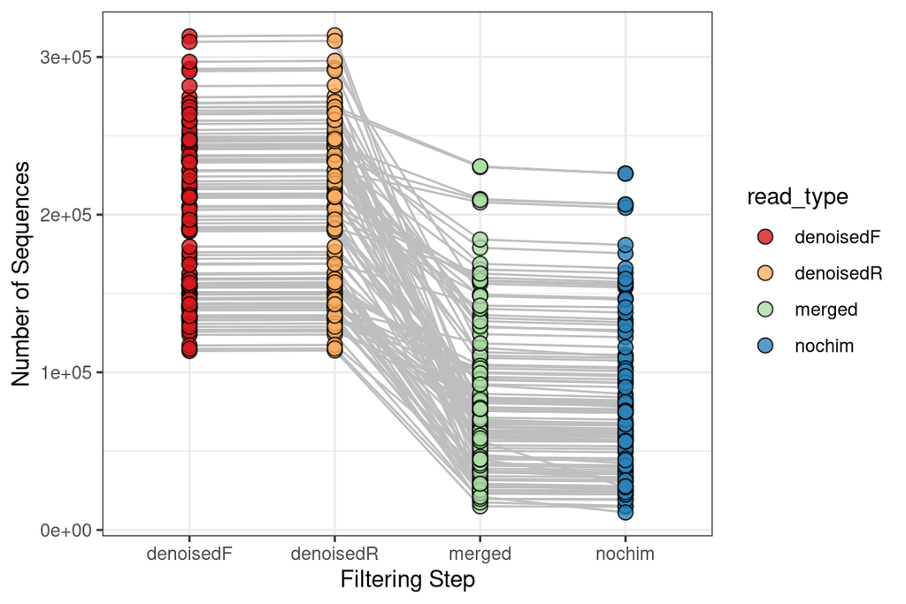

```r
# Plot it!
track_counts_df %>%
  pivot_longer(denoisedF:nochim, names_to = "read_type", values_to = "num_reads") %>%
  mutate(read_type = fct_relevel(read_type, "denoisedF", "denoisedR", "merged", "nochim")) %>%
  ggplot(aes(x = read_type, y = num_reads, fill = read_type)) +
  geom_line(aes(group = sample_names), color = "grey") +
  geom_point(shape = 21, size = 3, alpha = 0.8) +
  scale_fill_brewer(palette = "Spectral") +
  labs(x = "Filtering Step", y = "Number of Sequences") +
  theme_bw()
```

Now, let’s plot the number of sequences that have been maintained in our samples using `geom_histogram()`.

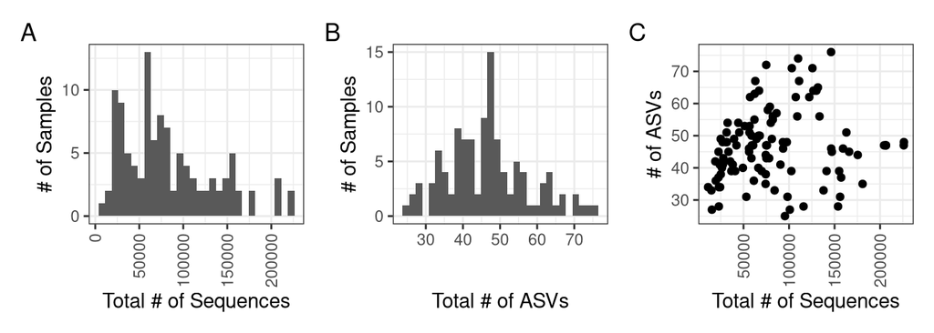

```r
plot_ReadDepth <-
  track_counts_df %>%
  ggplot(aes(x = nochim)) +
  geom_histogram() +
  labs(x = "Total # of Sequences", y = "# of Samples") +
  theme_bw() +
  theme(axis.text.x = element_text(angle = 90, vjust = 0.5, hjust=1))

# What is the ASV richness per sample?
plot_ASVRichness <-
  track_counts_df %>%
  ggplot(aes(x = num_ASVs)) +
  geom_histogram() +
  labs(x = "Total # of ASVs", y = "# of Samples") +
  theme_bw()

# Now, let's look at the relationship of ASVs and Sequencing depth
plot_ReadDepth_ASVRichness <-
  track_counts_df %>%
  ggplot(aes(x = nochim, y = num_ASVs)) +
  geom_point() +
  labs(x = "Total # of Sequences", y = "# of ASVs") +
  theme_bw() +
  theme(axis.text.x = element_text(angle = 90, vjust = 0.5, hjust=1))

# Show the plots together
plot_ReadDepth + plot_ASVRichness + plot_ReadDepth_ASVRichness +
    plot_annotation(tag_levels = 'A')
```

The figure above consists of three plots that summarize sequencing depth, ASV richness, and their relationship after DADA2 processing of 16S rRNA gene sequencing data.

**Panel A: Read Depth after DADA2:** Histogram of sequencing depth per sample (Total # of Sequences)

- The distribution seems bimodal, one centered around ~25,000 and the they centered around ~60,000 reads per sample.
- Most of the samples had a good sequencing depth ranging from 10,000 to 200,000 reads.

**Panel C: Read Depth vs ASV Richness:** Scatter plot showing the relationship between sequencing depth and ASV richness.

- Generally a positive correlation is expected, where samples with higher read depth tend to have more ASVs. However, the distribution of number of ASVs and total number of sequences doesn’t seem to be correlated.
- Some samples with high read depth have low ASVs, which could indicate presence of chimeras in these samples as many chimeras were detected and removed.

**Overall Interpretation & Considerations**

1. *Sequencing depth variation*: Although most samples cluster around a common sequencing depth, some samples have larger sequencing depth.
2. *ASV richness does not seem to depend on read depth trends*:
3. *Rarefaction or normalization may be needed*: The right plot suggests that richness estimates are not influenced by read depth, so rarefying or other statistical corrections might not be necessary for comparative analysis.

# Assign Taxonomy

Here, we will use the **silva database version 138.2**, which has been properly formatted for DADA2. The files came from this [DADA2-formatted reference databases website](https://benjjneb.github.io/dada2/training.html), which hosts several other reference taxonomy files for several popular taxonomic databases.

In this example, we are going to use the database that is pre-downloaded to the server at the following path: `/workdir/in_class_data/taxonomy/`. You are welcome to symbolically link the taxonomy files, however note that they are VERY LARGE. So, it is actually suggested here (for this one time) to use the absolute path here. However, we need to note that this would break our reproducibility!

## How does the taxonomy work?

The `assignTaxonomy` function implements the Ribosomal Database Project (RDP) Naive Bayesian Classifier algorithm described in Wang et al. (2007), published in Applied and Environmental Microbiology, with a kmer size of 8 and 100 bootstrap replicates.

```r
# Assign up to genus level
taxa_train <-
  assignTaxonomy(noChimeras_ASV_table,
                 refFasta = "/workdir/in_class_data/taxonomy/silva_nr99_v138.2_toGenus_trainset.fa.gz",
                 multithread = n_threads)

# Add the genus/species information
taxa_addSpecies <-
  addSpecies(taxa_train,
              refFasta = "/workdir/in_class_data/taxonomy/silva_v138.2_assignSpecies.fa.gz")

# Inspect the taxonomy
glimpse(taxa_addSpecies) # Note that the rownames are the ASV sequences!
```

```
##  chr [1:536, 1:7] "Bacteria" "Bacteria" "Bacteria" "Bacteria" "Bacteria" ...
##  - attr(*, "dimnames")=List of 2
##   ..$ : chr [1:536] "AATTTTCCGCAATGGGCGAAAGCCTGACGGAGCAATGCCGCGTGGAGGTAGAAGGCCCACGGGTCATGAACTTCTTTTCCCGGAGAAGAAGCAATGACGGTATCTGGGGAA"| __truncated__ "AATCTTGGACAATGGGCGAAAGCCCGATCCAGCAATATCGCGTGAGTGAAGAAGGGCAATGCCGCTTGTAAAGCTCTTTCGTCGAGTGCGCGATCATGACAAGACTCGAGG"| __truncated__ "AATTTTACGTAATGGGCG…
##   ..$ : chr [1:7] "Kingdom" "Phylum" "Class" "Order" ...
```

```r
# Let's removing the ASV sequence rownames for display only
taxa_print <- taxa_addSpecies
rownames(taxa_print) <- NULL
head(taxa_print)
```

```
##      Kingdom    Phylum            Class                 Order
## [1,] "Bacteria" "Cyanobacteriota" "Cyanobacteriia"      "Chloroplast"
## [2,] "Bacteria" "Pseudomonadota"  "Alphaproteobacteria" "Rickettsiales"
## [3,] "Bacteria" "Cyanobacteriota" "Cyanobacteriia"      "Chloroplast"
## [4,] "Bacteria" "Pseudomonadota"  "Alphaproteobacteria" "Rickettsiales"
## [5,] "Bacteria" "Cyanobacteriota" "Cyanobacteriia"      "Chloroplast"
## [6,] "Bacteria" "Cyanobacteriota" "Cyanobacteriia"      "Chloroplast"
##      Family         Genus Species
## [1,] NA             NA    NA
## [2,] "Mitochondria" NA    NA
## [3,] NA             NA    NA
## [4,] "Mitochondria" NA    NA
## [5,] NA             NA    NA
## [6,] NA             NA    NA
```

```r
#View(taxa_print)
```

# Export the Data

Remember from the beginning of the file under “Goals”, we wanted to export 4 different types of information:

1. ASV Count Table: `asv_table` (with and without sequence names)
2. ASV fasta file: `asvs_fasta` for building a phylogenetic tree at a later step.
3. Taxonomy Table `tax_table`
4. Sample Information: `sample_data` track the reads lots throughout DADA2 workflow.

## 1. ASV Tables

We will export the following two ASV count tables, which will be in “long” format where the **ASVs are in rows** and the **sample names are in the columns.**

### Structure of ASV tables

Let’s check that the ASVs are in the rows and the sample names are in the columns. If not, we can use the transpose function `t()` in R.

```r
# What's the current format of the ASV table?
head(rownames(noChimeras_ASV_table)) # Samples!
```

```
## [1] "SRR17327669_R1_filtered.fastq.gz" "SRR17327670_R1_filtered.fastq.gz"
## [3] "SRR17327671_R1_filtered.fastq.gz" "SRR17327672_R1_filtered.fastq.gz"
## [5] "SRR17327673_R1_filtered.fastq.gz" "SRR17327674_R1_filtered.fastq.gz"
```

```r
head(colnames(noChimeras_ASV_table)) # ASV Sequences
```

```
## [1] "AATTTTCCGCAATGGGCGAAAGCCTGACGGAGCAATGCCGCGTGGAGGTAGAAGGCCCAC…"
## [2] "AATCTTGGACAATGGGCGAAAGCCCGATCCAGCAATATCGCGTGAGTGAAGAAGGGCAAT…"
## [3] "AATTTTACGTAATGGGCGAAAGCCTGACGGAGCAATGTCGCGTGGAGGCAGAAGGCTCAC…"
## [4] "AATCTTGGACAATGGGCGAAAGCCCGATCCAACAATATCGCGTGAGTGAAGAAGGGCAAT…"
## [5] "AATTTTCCGCAATGGGCAAAAGCCTGATGGAGCAATGCCGCGTGGAGGTAGAAGGCCCAC…"
## [6] "AATATTGGACAATGGGCGAAAGCCTGACGGAGCAATGCCGCGTGGAGGTAGAAGGCCCAC…"
```

```r
# Therefore, we need to transpose the matrix
final_ASV_table_withSeqs <- t(noChimeras_ASV_table)

# Intuition check
head(rownames(final_ASV_table_withSeqs)) # ASV Sequences
```

```
## [1] "AATTTTCCGCAATGGGCGAAAGCCTGACGGAGCAATGCCGCGTGGAGGTAGAAGGCCCAC…"
## [2] "AATCTTGGACAATGGGCGAAAGCCCGATCCAGCAATATCGCGTGAGTGAAGAAGGGCAAT…"
## [3] "AATTTTACGTAATGGGCGAAAGCCTGACGGAGCAATGTCGCGTGGAGGCAGAAGGCTCAC…"
## [4] "AATCTTGGACAATGGGCGAAAGCCCGATCCAACAATATCGCGTGAGTGAAGAAGGGCAAT…"
## [5] "AATTTTCCGCAATGGGCAAAAGCCTGATGGAGCAATGCCGCGTGGAGGTAGAAGGCCCAC…"
## [6] "AATATTGGACAATGGGCGAAAGCCTGACGGAGCAATGCCGCGTGGAGGTAGAAGGCCCAC…"
```

```r
head(colnames(final_ASV_table_withSeqs)) # Sample names
```

```
## [1] "SRR17327669_R1_filtered.fastq.gz" "SRR17327670_R1_filtered.fastq.gz"
## [3] "SRR17327671_R1_filtered.fastq.gz" "SRR17327672_R1_filtered.fastq.gz"
## [5] "SRR17327673_R1_filtered.fastq.gz" "SRR17327674_R1_filtered.fastq.gz"
```

### Names in ASV tables

#### Fix Sample Names

Notice above that the sample names are actually file names. Let’s fix this!

> WARNING! This is an easy place where a silent error can step in where we could misname our samples, leading to catastrophe down the road. So, we need to be very careful and complete our checks and balances so we ensure the samples are not mixed up in the renaming process.

```r
# Remember at the top of the file we created a vector of sample names
head(sample_names)
```

```
## [1] "SRR17327669" "SRR17327670" "SRR17327671" "SRR17327672" "SRR17327673"
## [6] "SRR17327674"
```

```r
# Let's check with the actual column names
head(colnames(final_ASV_table_withSeqs)) # Sample names
```

```
## [1] "SRR17327669_R1_filtered.fastq.gz" "SRR17327670_R1_filtered.fastq.gz"
## [3] "SRR17327671_R1_filtered.fastq.gz" "SRR17327672_R1_filtered.fastq.gz"
## [5] "SRR17327673_R1_filtered.fastq.gz" "SRR17327674_R1_filtered.fastq.gz"
```

```r
# And then apply our sample name script to check, too
head(sapply(strsplit(colnames(final_ASV_table_withSeqs), "_"), `[`,1)) # Looks good!
```

```
## [1] "SRR17327669" "SRR17327670" "SRR17327671" "SRR17327672" "SRR17327673"
## [6] "SRR17327674"
```

```r
# Now, add a break in the script break if this isn't true!
# Let's make sure the sample names match the file names in the matrix.
stopifnot(sapply(strsplit(colnames(final_ASV_table_withSeqs), "_"), `[`,1) == sample_names)

# Now, we've done some checks to prove to ourselves there will be no silent errors,
# Let's rename!
colnames(final_ASV_table_withSeqs) <- sample_names
head(colnames(final_ASV_table_withSeqs))
```

```
## [1] "SRR17327669" "SRR17327670" "SRR17327671" "SRR17327672" "SRR17327673"
## [6] "SRR17327674"
```

#### Rename ASVs

Then, we can also fix the names of our ASVs for our second ASV table where we will replace the ASV sequence names with ASV_1, ASV_2

```r
# Give headers more manageable names
# First pull the ASV sequences from the rownames
ASV_seqs <- rownames(final_ASV_table_withSeqs)
ASV_seqs[1:5]
```

```
## [1] "AATTTTCCGCAATGGGCGAAAGCCTGACGGAGCAATGCCGCGTGGAGGTAGAAGGCCCAC…"
## [2] "AATCTTGGACAATGGGCGAAAGCCCGATCCAGCAATATCGCGTGAGTGAAGAAGGGCAAT…"
## [3] "AATTTTACGTAATGGGCGAAAGCCTGACGGAGCAATGTCGCGTGGAGGCAGAAGGCTCAC…"
## [4] "AATCTTGGACAATGGGCGAAAGCCCGATCCAACAATATCGCGTGAGTGAAGAAGGGCAAT…"
## [5] "AATTTTCCGCAATGGGCAAAAGCCTGATGGAGCAATGCCGCGTGGAGGTAGAAGGCCCAC…"
```

```r
# How many ASVs?
num_ASVs <- dim(final_ASV_table_withSeqs)[1] # select the number of rows
num_ASVs
```

```
## [1] 536
```

```r
# Make an empty vector the length of the number of ASVs,
# which is where we will place the new operational ASV names
ASV_headers <- vector(num_ASVs, mode = "character")

# Let's mae sure we have an empty vector!
ASV_headers[1:5]
```

```
## [1] "" "" "" "" ""
```

```r
length(ASV_headers) # looks good!
```

```
## [1] 536
```

```r
# Now, let's create a vector with ASV numbers
# loop through vector and fill it in with ASV names
for (i in 1:num_ASVs) {
  # Add leading zero to ASV name so they print in correct order.
  ASV_number <- sprintf("%04d", i)
  # Now, rename each spot in the ASV header vector as we loop through the for loop
  ASV_headers[i] <- paste(">ASV", ASV_number, sep = "_")
}

# Intuition check
ASV_headers[1:5]
```

```
## [1] ">ASV_0001" ">ASV_0002" ">ASV_0003" ">ASV_0004" ">ASV_0005"
```

```r
# Create a new ASV table, which will have the ASV numbers as names
# View(noChimeras_ASV_table) # To view the table
final_ASV_table <- final_ASV_table_withSeqs
glimpse(final_ASV_table)
```

```
##  int [1:536, 1:108] 71968 3021 455 202 264 138 252 0 0 77 ...
##  - attr(*, "dimnames")=List of 2
##   ..$ : chr [1:536] "AATTTTCCGCAATGGGCGAAAGCCTGACGGAGCAATGCCGCGTGGAGGTAGAAGGCCCACGGGTCATGAACTTCTTTTCCCGGAGAAGAAGCAATGACGGTATCTGGGGAA"| __truncated__ "AATCTTGGACAATGGGCGAAAGCCCGATCCAGCAATATCGCGTGAGTGAAGAAGGGCAATGCCGCTTGTAAAGCTCTTTCGTCGAGTGCGCGATCATGACAAGACTCGAGG"| __truncated__ "AATTTTACGTAATGGGCG…
##   ..$ : chr [1:108] "SRR17327669" "SRR17327670" "SRR17327671" "SRR17327672" ...
```

```r
## Replace the ASV seqs with the ASV numbers
row.names(final_ASV_table) <- sub(">", "", ASV_headers)
final_ASV_table[1:5, 1:5]
```

```
##          SRR17327669 SRR17327670 SRR17327671 SRR17327672 SRR17327673
## ASV_0001       71968       94380       97697      159669      117521
## ASV_0002        3021        3819        4978       11289        4957
## ASV_0003         455         696         636         621         376
## ASV_0004         202         416         339         546         288
## ASV_0005         264         402         359         324         247
```

```r
#View(final_ASV_table) # To view the table
```

### Write the ASV Tables!

```r
# 1. Write count table with ASV sequence names
write.table(final_ASV_table_withSeqs,
            file = "data/01_DADA2/ASV_table_withSeqNames.tsv",
            sep = "\t", quote = FALSE, col.names = NA)

# 2. Write count table with ASV numbered names (e.g. ASV_1, ASV_2, etc)
write.table(final_ASV_table,
            file = "data/01_DADA2/ASV_table.tsv",
            sep = "\t", quote = FALSE, col.names = NA)
```

## 2. ASV Fasta File

Now, let’s create a fasta file that has our ASV numbers with each of their corresponding ASV sequences. This file needs to be created because we will use it later to build a phylogenetic tree.

**Why do we need a phylogenetic tree?** Many widely used microbial ecology metrics rely on phylogenetic relationships to quantify community similarity. For example, there are phylogenetic alpha-diversity metrics like the [phylogenetic Hill Numbers](https://www.annualreviews.org/content/journals/10.1146/annurev-ecolsys-120213-091540) and also beta-diversity measures that incorporate the branch lengths of phylogenetic trees as it relates to community dissimilarity, [like the abundance-unweighted and abundance-weighted UniFrac dissimilarity metrics](https://journals.asm.org/doi/full/10.1128/aem.71.12.8228-8235.2005). These metrics consider species presence and their evolutionary distances, conveying relationships of communities through an ecological *and* evolutionary framework.

### Write the ASV Fasta File

```r
# Let's take our asv_headers
head(ASV_headers, n = 2)
```

```
## [1] ">ASV_0001" ">ASV_0002"
```

```r
# And combine it with their sequences
head(ASV_seqs, n = 2)
```

```
## [1] "AATTTTCCGCAATGGGCGAAAGCCTGACGGAGCAATGCCGCGTGGAGGTAGAAGGCCCAC…"
## [2] "AATCTTGGACAATGGGCGAAAGCCCGATCCAGCAATATCGCGTGAGTGAAGAAGGGCAAT…"
```

```r
# Combine in a fasta format with the cbind() function
ASV_fasta <- c(rbind(ASV_headers, ASV_seqs))
head(ASV_fasta, n = 4)
```

```
## [1] ">ASV_0001"
## [2] "AATTTTCCGCAATGGGCGAAAGCCTGACGGAGCAATGCCGCGTGGAGGTAGAAGGCCCAC…"
## [3] ">ASV_0002"
## [4] "AATCTTGGACAATGGGCGAAAGCCCGATCCAGCAATATCGCGTGAGTGAAGAAGGGCAAT…"
```

```r
# Then, let's write it to a fasta file!
# This will be our reference later on for which seq matches which ASV
write(ASV_fasta, "data/01_DADA2/ASVs.fasta")
```

## 3. Taxonomy Table

Before we actually write the taxonomy table, let’s put the ASV sequences as another column in our taxonomy table and then replace the rownames to be our numbered ASV names.

### Reformat Taxonomy

1. Move ASV sequences to column
2. Replace ASV rownames with ASV numbered names

> WARNING! This is another easy place where a silent error can step in!! Here, we could accidentally misname our ASVs. So, we need to be very careful and perform intuition checks to ensure that the ASV names are not mixed up in the renaming process.

```r
# Inspect the taxonomy table
dim(taxa_addSpecies) # ASVs are in rows and Kingdom, Phylum, etc in Columns
```

```
## [1] 536   7
```

```r
colnames(taxa_addSpecies) # Column names are Linnean Taxonomy
```

```
## [1] "Kingdom" "Phylum"  "Class"   "Order"   "Family"  "Genus"   "Species"
```

```r
head(rownames(taxa_addSpecies), n = 2) # ASV names are rownames
```

```
## [1] "AATTTTCCGCAATGGGCGAAAGCCTGACGGAGCAATGCCGCGTGGAGGTAGAAGGCCCAC…"
## [2] "AATCTTGGACAATGGGCGAAAGCCCGATCCAGCAATATCGCGTGAGTGAAGAAGGGCAAT…"
```

```r
class(taxa_addSpecies) # Character matrix
```

```
## [1] "matrix" "array"
```

```r
##### Prepare tax table
# 1. Add the ASV sequences from the rownames to a column
new_tax_table <-
  taxa_addSpecies%>%
  as.data.frame() %>%
  rownames_to_column(var = "ASVseqs")

# Intuition check
glimpse(new_tax_table)
```

```
## Rows: 536
## Columns: 8
## $ ASVseqs <chr> "AATTTTCCGCAATGGGCGAAAGCCTGACGGAGCAATGCCGCGTGGAGGTAGAAGGCCCACG…
## $ Kingdom <chr> "Bacteria", "Bacteria", "Bacteria", "Bacteria", "Bacteria", "B…
## $ Phylum  <chr> "Cyanobacteriota", "Pseudomonadota", "Cyanobacteriota", "Pseud…
## $ Class   <chr> "Cyanobacteriia", "Alphaproteobacteria", "Cyanobacteriia", "Al…
## $ Order   <chr> "Chloroplast", "Rickettsiales", "Chloroplast", "Rickettsiales"…
## $ Family  <chr> NA, "Mitochondria", NA, "Mitochondria", NA, NA, NA, NA, NA, "P…
## $ Genus   <chr> NA, NA, NA, NA, NA, NA, NA, NA, NA, "Pseudomonas", NA, NA, NA,…
## $ Species <chr> NA, NA, NA, NA, NA, NA, NA, NA, NA, NA, NA, NA, NA, NA, NA, NA…
```

```r
# IMPORTANT! Let's do our intuition check
# This is where we ensure we don't mix up the ASV names!
stopifnot(new_tax_table$ASVseqs == rownames(final_ASV_table_withSeqs))
# Now let's add the ASV names
rownames(new_tax_table) <- rownames(final_ASV_table)
head(new_tax_table)
```

```
##                                                                                                                                                                                                                                                                                                          …
## ASV_0001  AATTTTCCGCAATGGGCGAAAGCCTGACGGAGCAATGCCGCGTGGAGGTAGAAGGCCCAC…
## ASV_0002  AATCTTGGACAATGGGCGAAAGCCCGATCCAGCAATATCGCGTGAGTGAAGAAGGGCAAT…
## ASV_0003  AATTTTACGTAATGGGCGAAAGCCTGACGGAGCAATGTCGCGTGGAGGCAGAAGGCTCAC…
## ASV_0004 AATCTTGGACAATGGGCGAAAGCCCGATCCAACAATATCGCGTGAGTGAAGAAGGGCAAT…
## ASV_0005  AATTTTCCGCAATGGGCAAAAGCCTGATGGAGCAATGCCGCGTGGAGGTAGAAGGCCCAC…
## ASV_0006  AATATTGGACAATGGGCGAAAGCCTGACGGAGCAATGCCGCGTGGAGGTAGAAGGCCCAC…
##           Kingdom          Phylum               Class         Order
## ASV_0001 Bacteria Cyanobacteriota      Cyanobacteriia   Chloroplast
## ASV_0002 Bacteria  Pseudomonadota Alphaproteobacteria Rickettsiales
## ASV_0003 Bacteria Cyanobacteriota      Cyanobacteriia   Chloroplast
## ASV_0004 Bacteria  Pseudomonadota Alphaproteobacteria Rickettsiales
## ASV_0005 Bacteria Cyanobacteriota      Cyanobacteriia   Chloroplast
## ASV_0006 Bacteria Cyanobacteriota      Cyanobacteriia   Chloroplast
##                Family Genus Species
## ASV_0001         <NA>  <NA>    <NA>
## ASV_0002 Mitochondria  <NA>    <NA>
## ASV_0003         <NA>  <NA>    <NA>
## ASV_0004 Mitochondria  <NA>    <NA>
## ASV_0005         <NA>  <NA>    <NA>
## ASV_0006         <NA>  <NA>    <NA>
```

```r
### Final prep of tax table. Add new column with ASV names
ASV_tax_table <-
  new_tax_table %>%
  # add rownames from count table for phyloseq handoff
  mutate(ASV = rownames(final_ASV_table)) %>%
  # Reorder the columns
  dplyr::select(Kingdom, Phylum, Class, Order, Family, Genus, Species, ASV, ASVseqs)

# Assign the rownames, which is required by phyloseq
rownames(ASV_tax_table) <- ASV_tax_table$ASV

# Take a quick look
glimpse(ASV_tax_table)
```

```
## Rows: 536
## Columns: 9
## $ Kingdom <chr> "Bacteria", "Bacteria", "Bacteria", "Bacteria", "Bacteria", "B…
## $ Phylum  <chr> "Cyanobacteriota", "Pseudomonadota", "Cyanobacteriota", "Pseud…
## $ Class   <chr> "Cyanobacteriia", "Alphaproteobacteria", "Cyanobacteriia", "Al…
## $ Order   <chr> "Chloroplast", "Rickettsiales", "Chloroplast", "Rickettsiales"…
## $ Family  <chr> NA, "Mitochondria", NA, "Mitochondria", NA, NA, NA, NA, NA, "P…
## $ Genus   <chr> NA, NA, NA, NA, NA, NA, NA, NA, NA, "Pseudomonas", NA, NA, NA,…
## $ Species <chr> NA, NA, NA, NA, NA, NA, NA, NA, NA, NA, NA, NA, NA, NA, NA, NA…
## $ ASV     <chr> "ASV_0001", "ASV_0002", "ASV_0003", "ASV_0004", "ASV_0005", "A…
## $ ASVseqs <chr> "AATTTTCCGCAATGGGCGAAAGCCTGACGGAGCAATGCCGCGTGGAGGTAGAAGGCCCACG…
```

```r
# Intution check
stopifnot(ASV_tax_table$ASV == rownames(ASV_tax_table),
          rownames(ASV_tax_table) == rownames(ASV_tax_table))
```

### Write the Taxonomy Table

Now, let’s write out the taxonomy table

```r
# Write the table
write.table(ASV_tax_table,
            file = "data/01_DADA2/ASV_taxonomy.tsv",
            sep = "\t", quote = FALSE, col.names = NA)
```

## 4. Sample Data

Let’s save the `track_counts_df`, which can be useful for downstream analyses.

```r
# And save the track_counts_df a R object, which we will merge with metadata information in the next step of the analysis in nalysis/02_Taxonomic_Assignment.
save(track_counts_df, file = "data/01_DADA2/track_read_counts.RData")
```

# Final info for Reproducibility

## Check Render Time

```r
# Take the time now that we are at the end of the script
end_time <- Sys.time()
end_time
```

```
## [1] "2025-03-11 16:13:50 EDT"
```

```r
# Echo the elapsed time
elapsed_time <- round((end_time - start_time), 3)
elapsed_time
```

```
## Time difference of 29.778 mins
```